# cac 2 code

```python
import pandas as pd
import numpy as np
import matplotlib.pyplot as plt
import seaborn as sns
```

```python
df=pd.read_csv("CAC 2 (Responses) - Form Responses 1.csv")
```

```python
df.head()
```

|  | Timestamp | Course | State | Gender | Overall how would you rate your mental health?\n | Is there any history of mental health disorder in your family?\n | On average, how many hours do you sleep per day?\n | Have you ever used the counselling service provided by the college? | Family Structure | Is this the first time you're staying away from home? | How is prayer and meditation important in your daily life? | On average, how stressed are you? | How long have you been in Lavasa? | What strategies do you use to cope with stress and anxiety in your daily life? |
| --- | --- | --- | --- | --- | --- | --- | --- | --- | --- | --- | --- | --- | --- | --- |
| 0 | 10/10/2023 21:44:21 | MSc DS | Kerala | Male | 4 | No | 4-6 hours | No | Joint Family | Yes | 4 | 4 | Less than 6 months | Meditation |
| 1 | 10/10/2023 22:14:11 | MSc DS | Kerala | Female | 2 | No | Less than 4 hours | No | Nuclear Family | No | 3 | 4 | Less than 6 months | Listening music |
| 2 | 10/10/2023 22:15:16 | MSc DS | Uttar Pradesh | Female | 4 | No | 4-6 hours | No | Nuclear Family | No | 3 | 4 | Less than 6 months | Listening music |
| 3 | 10/10/2023 22:19:15 | MSc DS | Kerala | Female | 2 | No | 7-8 hours | Yes | Nuclear Family | No | 3 | 4 | Less than 6 months | Sleeping |
| 4 | 10/10/2023 22:28:00 | MSc DS | Other | Male | 3 | No | 4-6 hours | No | Nuclear Family | No | 5 | 4 | Less than 6 months | Sports |

```python
df.tail()
```

|  | Timestamp | Course | State | Gender | Overall how would you rate your mental health?\n | Is there any history of mental health disorder in your family?\n | On average, how many hours do you sleep per day?\n | Have you ever used the counselling service provided by the college? | Family Structure | Is this the first time you're staying away from home? | How is prayer and meditation important in your daily life? | On average, how stressed are you? | How long have you been in Lavasa? | What strategies do you use to cope with stress and anxiety in your daily life? |
| --- | --- | --- | --- | --- | --- | --- | --- | --- | --- | --- | --- | --- | --- | --- |
| 310 | 10/24/2023 14:33:02 | MBA | Kerala | Male | 4 | No | Less than 4 hours | No | Nuclear Family | Yes | 3 | 4 | Less than 6 months | Sleeping |
| 311 | 10/24/2023 14:33:26 | MBA | Kerala | Female | 4 | No | Less than 4 hours | No | Joint Family | No | 3 | 4 | Less than 6 months | Listening music |
| 312 | 10/24/2023 14:35:22 | MBA | Kerala | Female | 4 | No | Less than 4 hours | Yes | Joint Family | No | 2 | 5 | Less than 6 months | Sleeping |
| 313 | 10/24/2023 14:36:03 | MBA | Tamil Nadu | Female | 4 | No | Less than 4 hours | No | Joint Family | No | 3 | 4 | Less than 6 months | Listening music |
| 314 | 10/24/2023 14:36:55 | MBA | West Bengal | Male | 4 | No | 4-6 hours | No | Joint Family | Yes | 4 | 4 | Less than 6 months | Sports |

```python
df.columns
```

```
Index(['Timestamp', 'Course', 'State', 'Gender',
       'Overall how would you rate your mental health?\n',
       'Is there any history of mental health disorder in your family?\n',
       'On average, how many hours do you sleep per day?\n',
       'Have you ever used the counselling service provided by the college?',
       'Family Structure',
       'Is this the first time you're staying away from home?',
       'How is prayer and meditation important in your daily life?',
       'On average, how stressed are you? ',
       'How long have you been in Lavasa?',
       'What strategies do you use to cope with stress and anxiety in your daily life?'],
      dtype='object')
```

```python
df.drop(["Timestamp"],axis=1,inplace=True)  #removing timestamp
#changing column names for ease
df.columns=["Course","State","Gender","Mental Health Rating","Family History","Sleep Duration","Counselling Service Usage","Family Structure","First Time Away From Home","Importance of Prayer,Meditation","Stress Score","Length of Stay","Coping Strategies"]
#dropping values beyond scope of  study
df["State"]=df["State"].replace("Other",np.nan)
df["Course"]=df["Course"].replace("Other",np.nan)
#replacing course name for ease
df["Course"] = df["Course"].replace("MSc Global Finance and Analytics","Msc GFA")
df.dropna(inplace=True)
df.head(5)
```

|  | Course | State | Gender | Mental Health Rating | Family History | Sleep Duration | Counselling Service Usage | Family Structure | First Time Away From Home | Importance of Prayer,Meditation | Stress Score | Length of Stay | Coping Strategies |
| --- | --- | --- | --- | --- | --- | --- | --- | --- | --- | --- | --- | --- | --- |
| 0 | MSc DS | Kerala | Male | 4 | No | 4-6 hours | No | Joint Family | Yes | 4 | 4 | Less than 6 months | Meditation |
| 1 | MSc DS | Kerala | Female | 2 | No | Less than 4 hours | No | Nuclear Family | No | 3 | 4 | Less than 6 months | Listening music |
| 2 | MSc DS | Uttar Pradesh | Female | 4 | No | 4-6 hours | No | Nuclear Family | No | 3 | 4 | Less than 6 months | Listening music |
| 3 | MSc DS | Kerala | Female | 2 | No | 7-8 hours | Yes | Nuclear Family | No | 3 | 4 | Less than 6 months | Sleeping |
| 5 | MSc DS | West Bengal | Female | 1 | No | 4-6 hours | No | Nuclear Family | Yes | 3 | 5 | Less than 6 months | Watching movies/series |

```python
df.shape
```

```
(303, 13)
```

```python
count_df=pd.DataFrame(index=df.columns)
count_df["Null Values"]=df.isnull().sum()
count_df["Unique Values"]=df.nunique()
count_df
```

|  | Null Values | Unique Values |
| --- | --- | --- |
| Course | 0 | 13 |
| State | 0 | 27 |
| Gender | 0 | 3 |
| Mental Health Rating | 0 | 5 |
| Family History | 0 | 2 |
| Sleep Duration | 0 | 4 |
| Counselling Service Usage | 0 | 2 |
| Family Structure | 0 | 2 |
| First Time Away From Home | 0 | 2 |
| Importance of Prayer,Meditation | 0 | 5 |
| Stress Score | 0 | 5 |
| Length of Stay | 0 | 3 |
| Coping Strategies | 0 | 7 |

```python
df.size
```

```
3939
```

```python
df.dtypes
```

```
Course                             object
State                              object
Gender                             object
Mental Health Rating                int64
Family History                     object
Sleep Duration                     object
Counselling Service Usage          object
Family Structure                   object
First Time Away From Home          object
Importance of Prayer,Meditation     int64
Stress Score                        int64
Length of Stay                     object
Coping Strategies                  object
dtype: object
```

```python
df.info()
```

```
<class 'pandas.core.frame.DataFrame'>
Index: 303 entries, 0 to 314
Data columns (total 13 columns):
 #   Column                           Non-Null Count  Dtype
---  ------                           --------------  -----
 0   Course                           303 non-null    object
 1   State                            303 non-null    object
 2   Gender                           303 non-null    object
 3   Mental Health Rating             303 non-null    int64
 4   Family History                   303 non-null    object
 5   Sleep Duration                   303 non-null    object
 6   Counselling Service Usage        303 non-null    object
 7   Family Structure                 303 non-null    object
 8   First Time Away From Home        303 non-null    object
 9   Importance of Prayer,Meditation  303 non-null    int64
 10  Stress Score                     303 non-null    int64
 11  Length of Stay                   303 non-null    object
 12  Coping Strategies                303 non-null    object
dtypes: int64(3), object(10)
memory usage: 33.1+ KB
```

```python
df.describe()
```

|  | Mental Health Rating | Importance of Prayer,Meditation | Stress Score |
| --- | --- | --- | --- |
| count | 303.000000 | 303.000000 | 303.000000 |
| mean | 3.069307 | 3.224422 | 3.587459 |
| std | 1.144443 | 1.202562 | 1.147171 |
| min | 1.000000 | 1.000000 | 1.000000 |
| 25% | 2.000000 | 2.000000 | 3.000000 |
| 50% | 3.000000 | 3.000000 | 4.000000 |
| 75% | 4.000000 | 4.000000 | 4.000000 |
| max | 5.000000 | 5.000000 | 5.000000 |

Observation: 25th percentile is 3. which means 75% of respondents are facing average/above-average stress

```python
df.shape
```

```
(303, 13)
```

```python
df.head()
```

|  | Course | State | Gender | Mental Health Rating | Family History | Sleep Duration | Counselling Service Usage | Family Structure | First Time Away From Home | Importance of Prayer,Meditation | Stress Score | Length of Stay | Coping Strategies |
| --- | --- | --- | --- | --- | --- | --- | --- | --- | --- | --- | --- | --- | --- |
| 0 | MSc DS | Kerala | Male | 4 | No | 4-6 hours | No | Joint Family | Yes | 4 | 4 | Less than 6 months | Meditation |
| 1 | MSc DS | Kerala | Female | 2 | No | Less than 4 hours | No | Nuclear Family | No | 3 | 4 | Less than 6 months | Listening music |
| 2 | MSc DS | Uttar Pradesh | Female | 4 | No | 4-6 hours | No | Nuclear Family | No | 3 | 4 | Less than 6 months | Listening music |
| 3 | MSc DS | Kerala | Female | 2 | No | 7-8 hours | Yes | Nuclear Family | No | 3 | 4 | Less than 6 months | Sleeping |
| 5 | MSc DS | West Bengal | Female | 1 | No | 4-6 hours | No | Nuclear Family | Yes | 3 | 5 | Less than 6 months | Watching movies/series |

```python
df.to_csv("cleaned_data.csv")
```

```python
df=pd.read_csv("cleaned_data.csv")
```

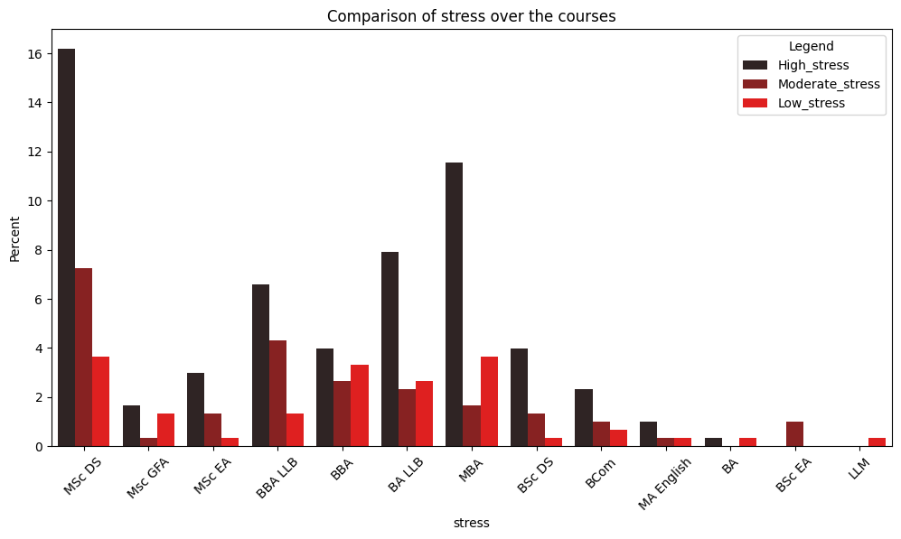

```python
import seaborn as sns
import matplotlib.pyplot as plt
df["Stress Score"] = df["Stress Score"].replace(1,"Low_stress")
df["Stress Score"] = df["Stress Score"].replace(2,"Low_stress")
df["Stress Score"] = df["Stress Score"].replace(3,"Moderate_stress")
df["Stress Score"] = df["Stress Score"].replace(4,"High_stress")
df["Stress Score"] = df["Stress Score"].replace(5,"High_stress")
df["Course"] = df["Course"].replace("MSc Global Finance and Analytics","Msc GFA")
plt.figure(figsize=(12, 6))
sns.countplot(x='Course', hue='Stress Score', data=df,palette='dark:red',stat="percent")
plt.xlabel('stress')
plt.ylabel('Percent')
plt.title('Comparison of stress over the courses')
plt.xticks(rotation=45)
plt.legend(title='Legend')
plt.show()
```

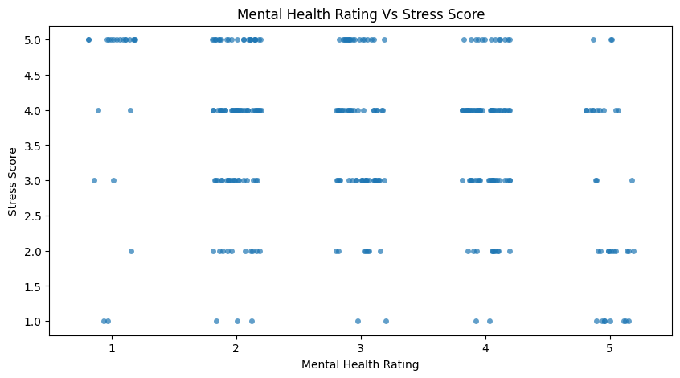

```python
df=pd.read_csv("cleaned_data.csv")
plt.figure(figsize=(10,5))

sns.stripplot(y=df["Stress Score"],x=df["Mental Health Rating"],size=5,jitter=.2,alpha=0.7)
plt.title("Mental Health Rating Vs Stress Score")
plt.xlabel("Mental Health Rating")
plt.ylabel("Stress Score")
plt.show()
plt.close()
```

observation: a lot of the people who claimed they had good mental health, had high stress levels. this shows a lack of awareness among people as they are unable to identify their own mental health situation.

```python
df["Mental Health Rating"] = df["Mental Health Rating"].replace(1,"Low_Mental_Health")
df["Mental Health Rating"] = df["Mental Health Rating"].replace(2,"Low_Mental_Health")
df["Mental Health Rating"] = df["Mental Health Rating"].replace(3,"Average_Mental_Health")
df["Mental Health Rating"] = df["Mental Health Rating"].replace(4,"Good_Mental_Health")
df["Mental Health Rating"] = df["Mental Health Rating"].replace(5,"Good_Mental_Health")
mental_health_count=df.value_counts(["Mental Health Rating"])
mental_health_frame=mental_health_count.to_frame()
mental_health_frame.reset_index(inplace=True)
mental_health_frame.sort_values(by="count",ascending=True,inplace=True)
mental_health_frame
```

|  | Mental Health Rating | count |
| --- | --- | --- |
| 2 | Average_Mental_Health | 74 |
| 1 | Low_Mental_Health | 110 |
| 0 | Good_Mental_Health | 119 |

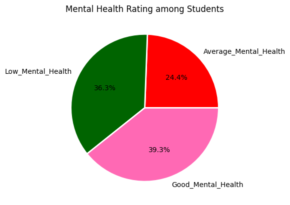

```python
label_data= mental_health_frame["Mental Health Rating"]
count_data = mental_health_frame["count"]


plt.pie(count_data, labels=label_data,autopct='%1.1f%%',wedgeprops = { 'linewidth' : 2, 'edgecolor' : 'white' },colors=["red","darkgreen","hotpink","purple","orange"],startangle=0)
plt.title("Mental Health Rating among Students")
plt.show()
```

Insight: Approx. 40% of respondents have good mental health

```python
df["Stress Score"] = df["Stress Score"].replace(1,"Low_stress")
df["Stress Score"] = df["Stress Score"].replace(2,"Low_stress")
df["Stress Score"] = df["Stress Score"].replace(3,"Moderate_stress")
df["Stress Score"] = df["Stress Score"].replace(4,"High_stress")
df["Stress Score"] = df["Stress Score"].replace(5,"High_stress")
stress_count=df.value_counts(["Stress Score"])
stress_frame=stress_count.to_frame()
stress_frame.reset_index(inplace=True)
stress_frame.sort_values(by="count",ascending=True,inplace=True)
stress_frame
```

|  | Stress Score | count |
| --- | --- | --- |
| 2 | Low_stress | 55 |
| 1 | Moderate_stress | 71 |
| 0 | High_stress | 177 |

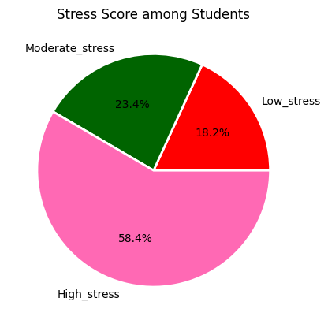

```python
label_data= stress_frame["Stress Score"]
count_data = stress_frame["count"]


plt.pie(count_data, labels=label_data,autopct='%1.1f%%',wedgeprops = { 'linewidth' : 2, 'edgecolor' : 'white' },colors=["red","darkgreen","hotpink","purple","orange"],startangle=0)
plt.title("Stress Score among Students")
plt.show()
```

Insight: High Stress levels among students. Approx 58% of respondents report high stress.

```python
import plotly.express as px
```

```python
df2=df.value_counts(["Length of Stay","Stress Score"])
df3=df2.to_frame()
df3.reset_index(inplace=True)
```

```python
# %pip install nbformat
```

```python
fig = px.scatter(x="Stress Score", y="Length of Stay",size_max=60,size="count",data_frame=df3)
fig.update_layout(title_text = "Length of stay Vs Stress",showlegend = True)

fig.show()
```

[output not shown]

Insight: As one gets used to the place, their stress levels go down. Among the newbies, 58% respondents experienced high levels of stress. 66% of respondents who stayed here for more than 1 year experience high level stress. However, only 30 % of people who have been in Lavasa for more than 2 years experience high stress. Those who have been here for more than 2 years are in courses like BA LLB,etc. With more time they get are able to get accustomed to Lavasa. However, the other categories include a large percent of students in Master Courses, who dont have the luxury of time in Lavasa.

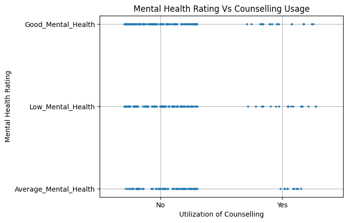

```python
sns.stripplot(x=df["Counselling Service Usage"],y=df["Mental Health Rating"],size=3,jitter=.3)
plt.xlabel('Utilization of Counselling')
plt.ylabel('Mental Health Rating')
plt.title("Mental Health Rating Vs Counselling Usage")
plt.grid(True)
plt.show()
```

Insight: Irrespective of Mental health, a majority of respondents are not using the counselling services provided.

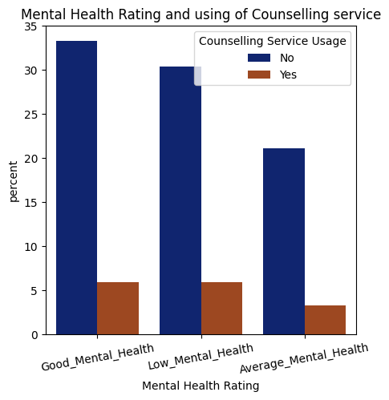

```python
plt.figure(figsize=(5,5))
sns.countplot(hue="Counselling Service Usage",x="Mental Health Rating",data=df,palette="dark",stat="percent")

plt.title("Mental Health Rating and using of Counselling service")
plt.xticks(rotation=10)
plt.show()
```

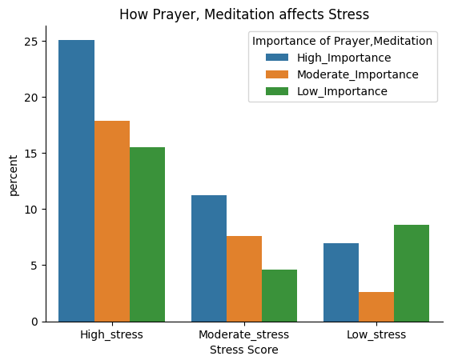

```python
df["Importance of Prayer,Meditation"] = df["Importance of Prayer,Meditation"].replace(1,"Low_Importance")
df["Importance of Prayer,Meditation"] = df["Importance of Prayer,Meditation"].replace(2,"Low_Importance")
df["Importance of Prayer,Meditation"] = df["Importance of Prayer,Meditation"].replace(3,"Moderate_Importance")
df["Importance of Prayer,Meditation"] = df["Importance of Prayer,Meditation"].replace(4,"High_Importance")
df["Importance of Prayer,Meditation"] = df["Importance of Prayer,Meditation"].replace(5,"High_Importance")
sns.countplot(hue="Importance of Prayer,Meditation",x="Stress Score",data=df,stat="percent")
sns.despine(top=True)
plt.title("How Prayer, Meditation affects Stress")
plt.show()
```

Respondents who report high stress levels have higher importance for prayer and meditation.

```python
df=pd.read_csv("cleaned_data.csv")
g1=df.set_index("Counselling Service Usage")
used_g_form=g1.loc[["No"]]
```

[figure not shown]

```python
plt.figure(figsize=(5,5))
plt.hist(used_g_form["Mental Health Rating"],edgecolor="white",bins=[0.5,1.5,2.5,3.5,4.5,5.5],color="red")
plt.xlabel("Stress Score")
plt.ylabel("No. of Students not using Counselling Services")
plt.title("Stress Score among students not using Counselling service")
plt.show()
```

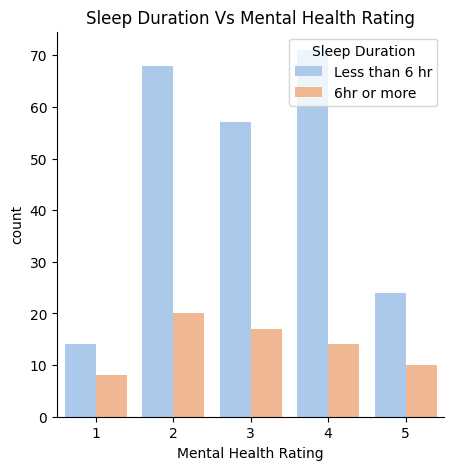

```python
df["Sleep Duration"].replace("Less than 4 hours","Less than 6 hr",inplace=True)
df["Sleep Duration"].replace("4-6 hours","Less than 6 hr",inplace=True)
df["Sleep Duration"].replace("7-8 hours","6hr or more",inplace=True)
df["Sleep Duration"].replace("More than 8 hours","6hr or more",inplace=True)
plt.figure(figsize=(5,5))
sns.countplot(hue="Sleep Duration",x="Mental Health Rating",data=df,palette="pastel")
sns.despine(top=True)
plt.title("Sleep Duration Vs Mental Health Rating")

plt.show()
```

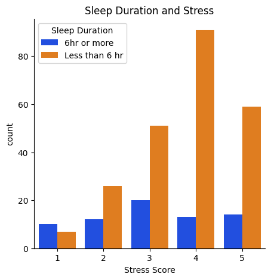

```python
plt.figure(figsize=(5,5))
sns.countplot(hue="Sleep Duration",x="Stress Score",data=df,palette="bright")
sns.despine(top=True,right=True)
plt.title("Sleep Duration and Stress")
plt.show()
```

Therefore less sleep => more stress Explanation for Anomaly in the case of those with stress score=5 could be that people tend to escape through sleep.

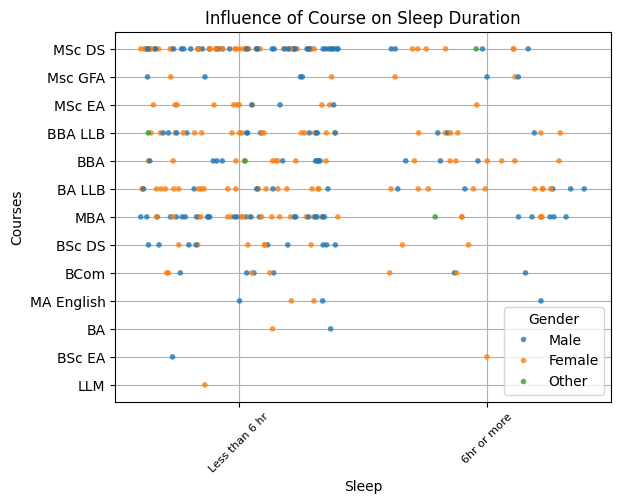

```python
# df["Sleeping"]=df["Sleeping"].replace("7-8 hours","good")
# df["Sleeping"]=df["Sleeping"].replace("More than 8 hours","good")
# df["Sleeping"]=df["Sleeping"].replace("4-6 hours","modarate")
# df["Sleeping"]=df["Sleeping"].replace("Less than 4 hours","bad")
sns.stripplot(x=df["Sleep Duration"],y=df["Course"],size=4,jitter=.4,alpha=.8,hue=df["Gender"],)
plt.xlabel('Sleep')
plt.ylabel('Courses')
plt.title('Influence of Course on Sleep Duration')
plt.grid(True)
plt.xticks(rotation=45,fontsize=8)
plt.show()
```

Sleep is less in Msc Ds, MBA, BA LLB, BBA LLB

Insight: Students in MBA and MSc Data SCience report high levels of stress when compared to others. Also, a large number of students report high levels of stress.

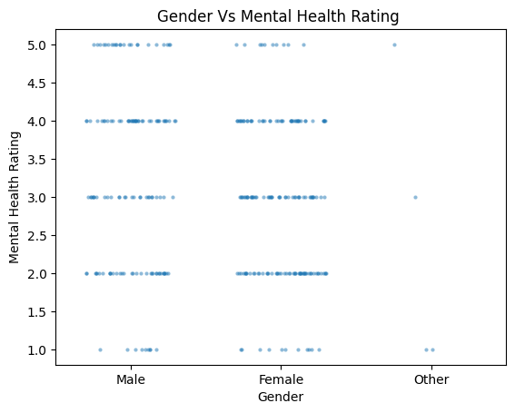

```python
sns.stripplot(x=df["Gender"],y=df["Mental Health Rating"],size=3,jitter=.3,alpha=0.5 )
plt.xlabel('Gender')
plt.ylabel("Mental Health Rating")
plt.title('Gender Vs Mental Health Rating ')
plt.show()
```

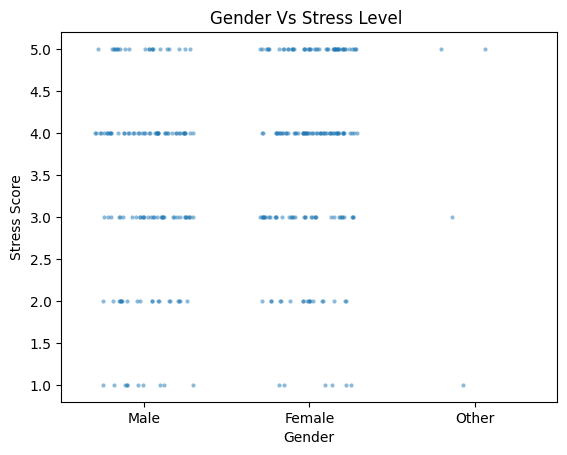

```python
sns.stripplot(x=df["Gender"],y=df["Stress Score"],size=3,jitter=.3,alpha=0.5 )
plt.xlabel('Gender')
plt.ylabel("Stress Score")
plt.title('Gender Vs Stress Level ')
plt.show()
```

Females are more stressed than males

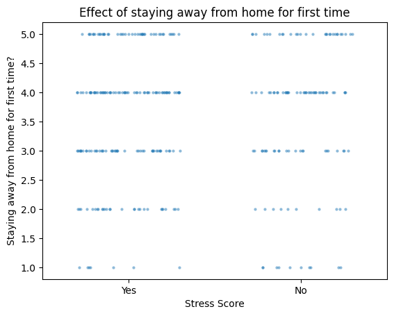

```python
sns.stripplot(x=df["First Time Away From Home"],y=df["Stress Score"],size=3,jitter=.3,alpha=0.5)
plt.xlabel('Stress Score')
plt.ylabel('Staying away from home for first time?')
plt.title('Effect of staying away from home for first time')
plt.show()
```

Those who stay away from home for the first time are more stressed

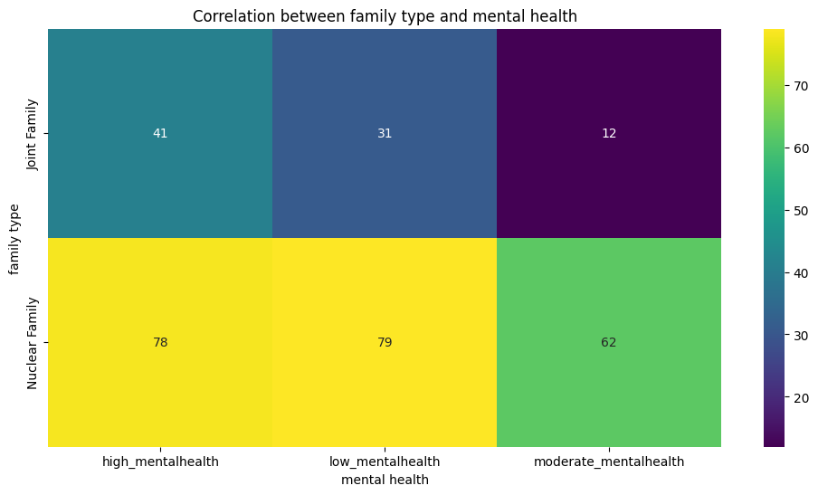

```python
df["Mental Health Rating"]=df["Mental Health Rating"].replace(1,"low_mentalhealth")
df["Mental Health Rating"]=df["Mental Health Rating"].replace(2,"low_mentalhealth")
df["Mental Health Rating"]=df["Mental Health Rating"].replace(3,"moderate_mentalhealth")
df["Mental Health Rating"]=df["Mental Health Rating"].replace(4,"high_mentalhealth")
df["Mental Health Rating"]=df["Mental Health Rating"].replace(5,"high_mentalhealth")
pivot_table = df.groupby(['Family Structure', 'Mental Health Rating']).size().unstack(fill_value=0)

plt.figure(figsize=(12, 6))
sns.heatmap(pivot_table, annot=True, cmap='viridis', fmt='d')
plt.xlabel('mental health')
plt.ylabel('family type')
plt.title('Correlation between family type and mental health')
plt.show()
```

inconclusive evidence

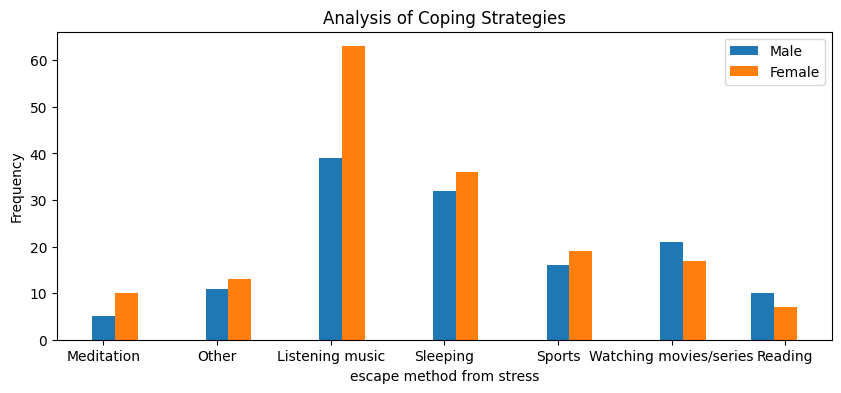

```python
df['Gender']=df['Gender'].replace("Other",np.nan)
df.dropna(inplace=True)
male_data = df[df['Gender'] == 'Male']
female_data = df[df['Gender'] == 'Female']
male_satisfaction = male_data["Coping Strategies"]
female_satisfaction = female_data["Coping Strategies"]

plt.figure(figsize=(10, 4))
plt.hist(male_satisfaction, bins=30, alpha=1, label='Male',align = 'left')
plt.hist(female_satisfaction, bins=30, alpha=1, label='Female',align = 'right')
plt.xlabel('escape method from stress')
plt.ylabel('Frequency')
plt.title('Analysis of Coping Strategies')
plt.legend()
plt.show()
```